# Ford GoBike Dataset Exploratory Analysis

## Data Exploration

### We would like to explore the relationships between the variables in the following manner:

#### A- Univariant Exploration:

1- Gender Split

2- User type split

3- Most frequent duration

4- Frequency of Trip vectorized length

5- Bike Share Split

6- Most frequent Start Days

7- Most frequent Start Hours

8- Most frequent Start Date

9- Age Split

10- Age Group Split

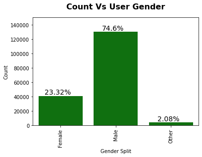

```python
ax = sns.countplot(data=df, x='member_gender', color='green');
for p in ax.patches:
    ax.annotate(f'{(100*p.get_height()/df.shape[0]).round(2)}%', (p.get_x()+0.35, p.get_height()), ha='center', va='bottom', color='black', size=14)
plt.xlabel('Gender Split');
plt.ylim(0,150000)
plt.xticks(rotation=90);
plt.ylabel('Count');
plt.title('Count Vs User Gender', y=1.05, fontsize=16, fontweight='bold', color = 'black');
```

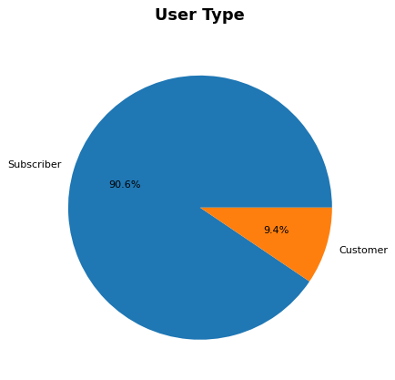

```python
fig=plt.figure(figsize=(6, 6), dpi= 80, facecolor='w', edgecolor='k')
plt.pie(df['user_type'].value_counts(),labels=df['user_type'].value_counts().index,autopct= '%1.1f%%')
plt.title('User Type', y=1.05, fontsize=16, fontweight='bold', color = 'black');
```

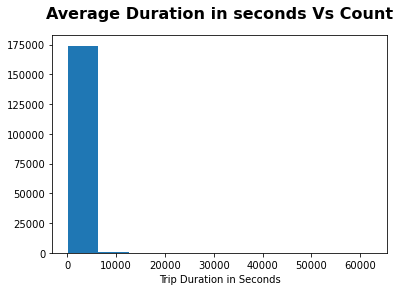

```python
plt.hist(data=df, x='duration_sec');
plt.xlabel('Trip Duration in Seconds');
plt.title('Average Duration in seconds Vs Count', y=1.05, fontsize=16, fontweight='bold', color = 'black');
```

```python
#checking for outliers at the 99%
df.duration_sec.describe(percentiles=[.99])
```

```
count    174668.000000
mean        672.109511
std         954.584874
min          61.000000
50%         510.000000
99%        3045.330000
max       62452.000000
Name: duration_sec, dtype: float64
```

From the Above 2 cells we can safely drop the outliers above 1 hour of rental (3600 second)

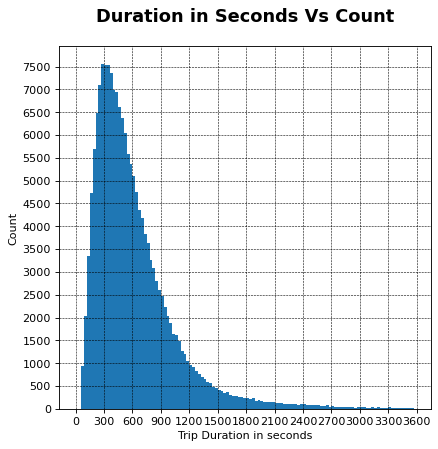

```python
fig=plt.figure(figsize=(6,6), dpi= 80, facecolor='w', edgecolor='k')

bins = np.arange(0, 3600, 30)
ticks = np.arange(0, 3900, 300)
yticks = np.arange(0,8000,500)
plt.hist(data=df, x='duration_sec', bins=bins);
plt.xticks(ticks);
plt.yticks(yticks);
plt.xlabel('Trip Duration in seconds');
plt.ylabel('Count')
plt.title('Duration in Seconds Vs Count', y=1.05, fontsize=16, fontweight='bold', color = 'black');
plt.grid(color = 'black', linestyle = '--', linewidth = 0.5);
```

```python
print('Mean Trip Duration = {} Seconds '.format(df['duration_sec'].mean()))
print('Median of Trip Duration = {} Seconds '.format(df['duration_sec'].median()))
print('Mode of Trip Duration = {} Seconds '.format(mode(df['duration_sec'])))
```

```
Mean Trip Duration = 672.1095106144228 Seconds
Median of Trip Duration = 510.0 Seconds
Mode of Trip Duration = 272 Seconds
```

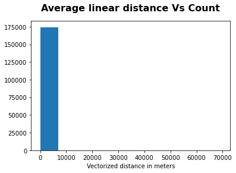

```python
plt.hist(data=df, x='linear_distance_meters');
plt.xlabel('Vectorized distance in meters');
plt.title('Average linear distance Vs Count', y=1.05, fontsize=16, fontweight='bold', color = 'black');
```

```python
#checking for outliers at the 95%
df.linear_distance_meters.describe(percentiles=[.95])
```

```
count    174668.000000
mean       1689.477094
std        1096.628190
min           0.000000
50%        1429.000000
95%        3790.000000
max       69469.000000
Name: linear_distance_meters, dtype: float64
```

From the Above 2 cells we'll drop the maximum 5% of outliers

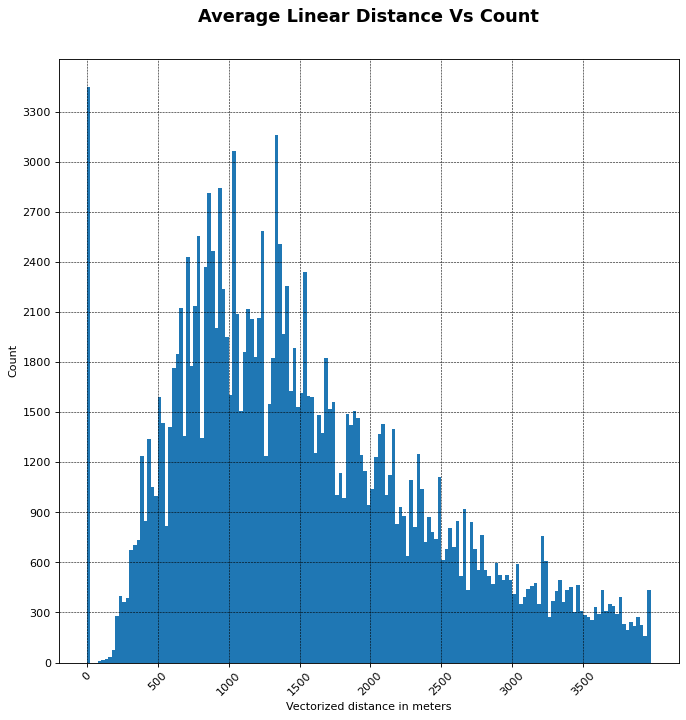

```python
fig=plt.figure(figsize=(10,10), dpi= 80, facecolor='w', edgecolor='k')

bins = np.arange(0, 4000, 25)
ticks = np.arange(0, 4000, 500)
yticks = np.arange(0,3600,300)
plt.hist(data=df, x='linear_distance_meters', bins=bins);
plt.xticks(ticks, rotation=45);
plt.yticks(yticks);
plt.xlabel('Vectorized distance in meters');
plt.ylabel('Count')
plt.title('Average Linear Distance Vs Count', y=1.05, fontsize=16, fontweight='bold', color = 'black');
plt.grid(color = 'black', linestyle = '--', linewidth = 0.5);
```

```python
print('Mean Trip Displacement = {} Km '.format(df['linear_distance_meters'].mean()/1000))
print('Median of Displacement = {} Km '.format(df['linear_distance_meters'].median()/1000))
print('Mode of Trip Displacement = {} Km '.format(mode(df['linear_distance_meters'])/1000))
```

```
Mean Trip Displacement = 1.6894770936863077 Km
Median of Displacement = 1.429 Km
Mode of Trip Displacement = 0.0 Km
```

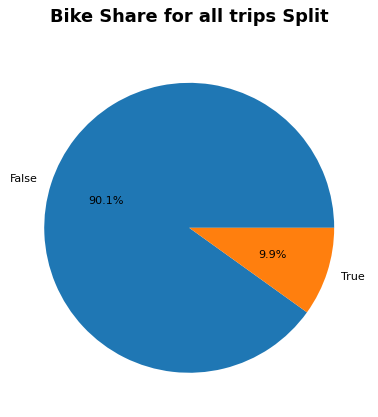

```python
fig=plt.figure(figsize=(6, 6), dpi= 80, facecolor='w', edgecolor='k')
plt.pie(df['bike_share_for_all_trip'].value_counts(),labels=df['bike_share_for_all_trip'].value_counts().index,autopct= '%1.1f%%')
plt.title('Bike Share for all trips Split', y=1.05, fontsize=16, fontweight='bold', color = 'black');
```

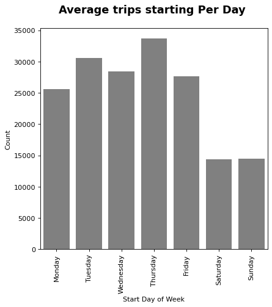

```python
order=['Monday', 'Tuesday', 'Wednesday', 'Thursday', 'Friday', 'Saturday', 'Sunday']

fig=plt.figure(figsize=(6,6), dpi= 80, facecolor='w', edgecolor='k')
plt.xticks(rotation=90);


#plotting a count plot


sns.countplot(data=df, x='start_day', color='gray', order=order);
plt.xlabel('Start Day of Week');
plt.ylabel('Count');
plt.title('Average trips starting Per Day ', y=1.05, fontsize=16, fontweight='bold', color = 'black');
```

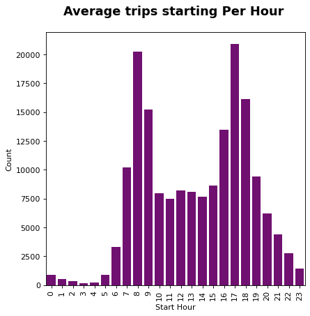

```python
fig=plt.figure(figsize=(6,6), dpi= 80, facecolor='w', edgecolor='k')
plt.xticks(rotation=90);

sns.countplot(data=df, x='start_hour', color='purple');
plt.xlabel('Start Hour');
plt.ylabel('Count');
plt.title('Average trips starting Per Hour ', y=1.05, fontsize=16, fontweight='bold', color = 'black');
```

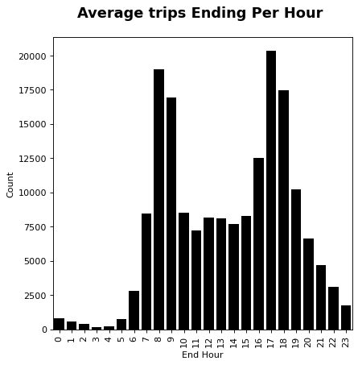

```python
fig=plt.figure(figsize=(6,6), dpi= 80, facecolor='w', edgecolor='k')
plt.xticks(rotation=90);



sns.countplot(data=df, x='end_hour', color='00');
plt.xlabel('End Hour');
plt.ylabel('Count');
plt.title('Average trips Ending Per Hour ', y=1.05, fontsize=16, fontweight='bold', color = 'black');
```

The Above two plots show that most trips occur in the usual working hours with spikes at around 8 & 9am in addition to 5 & 6 pm which is consistent with the typical working hours which is still against the recreational use hypothesis so the starting hours needs to be plotted with the weekday, duration & distance in multi variant plots to further investigate

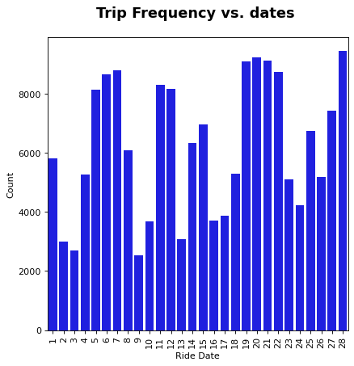

```python
fig=plt.figure(figsize=(6,6), dpi= 80, facecolor='w', edgecolor='k')
plt.xticks(rotation=90);

#plotting a count plot
sns.countplot(data=df, x='start_date', color='b');
plt.xlabel('Ride Date');
plt.ylabel('Count');
plt.title('Trip Frequency vs. dates ', y=1.05, fontsize=16, fontweight='bold', color = 'black');
```

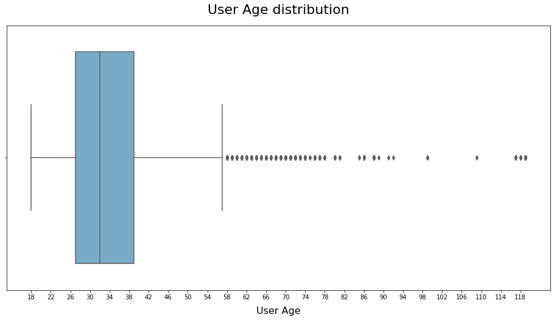

```python
plt.figure(figsize=(16,8))
sns.boxplot(data=df, x='age', palette='Blues', orient='h')
plt.title("User Age distribution", fontsize=22, y=1.03)
plt.xlabel("User Age", fontsize=16, labelpad=10)
plt.xticks(np.arange(18,122,4))
plt.show()
```

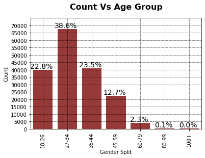

```python
ax = sns.countplot(data=df, x='age_group', color='brown');
for p in ax.patches:
    ax.annotate(f'{(100*p.get_height()/df.shape[0]).round(1)}%', (p.get_x()+0.35, p.get_height()), ha='center', va='bottom', color='black', size=14)
plt.xlabel('Gender Split');
plt.ylim(0,75000)
plt.yticks(np.arange(0,75000,5000));
plt.xticks(rotation=90);
plt.ylabel('Count');
plt.title('Count Vs Age Group', y=1.05, fontsize=16, fontweight='bold', color = 'black');
plt.grid(color = 'black', linestyle = '--', linewidth = 0.5);
```

### Univariant Exploration Observations

1- Gender Split: Males = 74.6% Females = 23.3% Other = 2.1%

2- 90.6% of users are subscribers & only 9.4% are customers

5- Almost 10% of users soley rely on bike share which is a pretty good percentage

6- Peak days seem to be during weekdays which suggests the use of bikeshare for commuting to & from work

7- Peak hours seem to be around 8-9am & 5-6pm which agrees with the above commuting hypothesis

9- Most users lie in the range between 18 & 57 years old with some outliers ranging up to the age of 120 years old.

10- The distribution between age groups shows that 38.6% of users are between 27-34, 23.5% between 35-44, 22.8% between 18-26, 12.7% between 45-59 & 2.4% above the age of 60

### B- Bivariant Exploration:

### Average Distance vs.:

1- Gender

2- User type

3- Duration

4- Bike Share for all

6- Start Day

7- Start Hour

8- Start Date

9- Age

10- Age Group

### Average Duration vs.:

1- Gender

2- User type

3- Bike Share for all

4- Start Day

5- Start Hour

6- Start Date

7- Age Group

### Count vs. :

1- Gender & User Type

2- Gender & Age Group

3- Gender & Day

4- Age Group & User Type

5- Age Group & Day

6- Weekday & Hour